Now, run script.

Compare to univariate results:

We can see that our method is more powerful than both univariate and multivariate approahces:

```r
lf.mash=read.table("lipid_data_signedzlfsr.txt")[,-1]
lf.bma=read.table("lipid_data_signedz_bmaonlylfsr.txt")[,-1]
lf.ash=read.table("lipids_univariateashtspec.lfsr.txt")
thresh=0.05
mean(lf.mash<thresh)
```

```
## [1] 0.1353341
```

```r
mean(lf.ash<thresh)
```

```
## [1] 0.032669
```

```r
mean(lf.bma<thresh)
```

```
## [1] 0.06285508
```

We can also ask how many SNPs are less than the threshold in at least one subgroup:

```r
min.mash=apply(lf.mash,1,min);sum(min.mash<0.05)
```

```
## [1] 28919
```

```r
min.bma=apply(lf.bma,1,min);sum(min.bma<0.05)
```

```
## [1] 15764
```

```r
min.ash=apply(lf.ash,1,min);sum(min.ash<0.05)
```

```
## [1] 9396
```

And much better than joint method like BMA. After training on 40,000 snps and testing on a unique set of 40,000 aditional snps, we learn the test set likelihood:

```r
sum(log(test.lik%*%pis.train))
cat total.lik.bma.lite
-315326.50
cat total.lik.mash
 -259030.11
```

Let’s look at the covariance patterns captured:

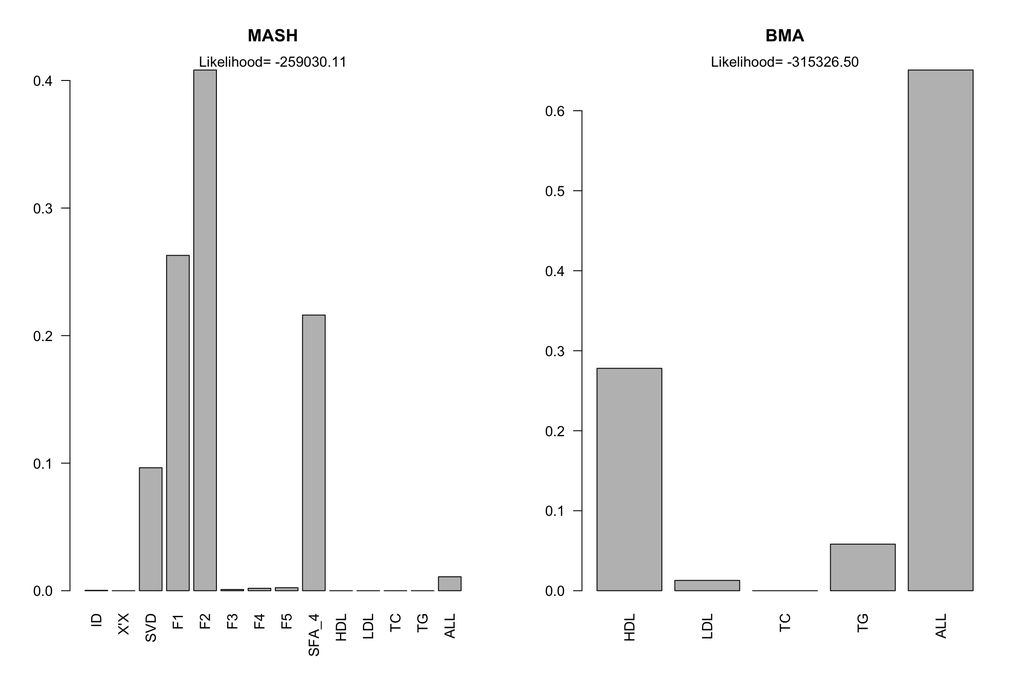

```r
sum(colSums(pi.mat[,1:9]))
```

```
## [1] 0.9890654
```

```r
colSums(pi.bma.mat)[5]
```

```
##       ALL
## 0.6508965
```

In fact, let’s examine the patterns.

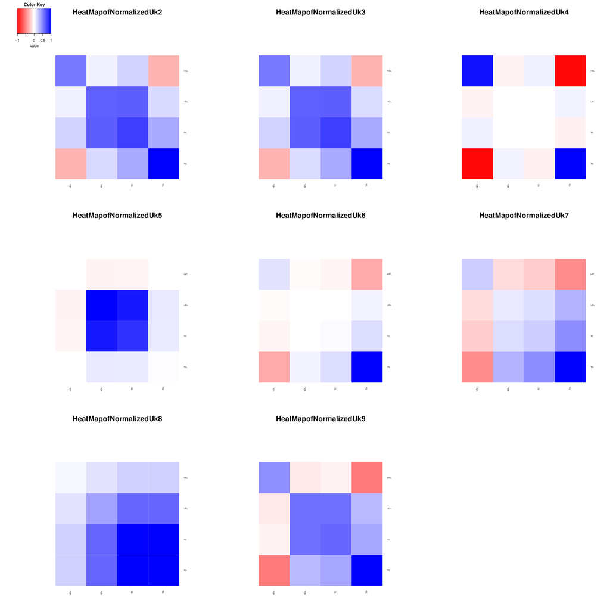

.

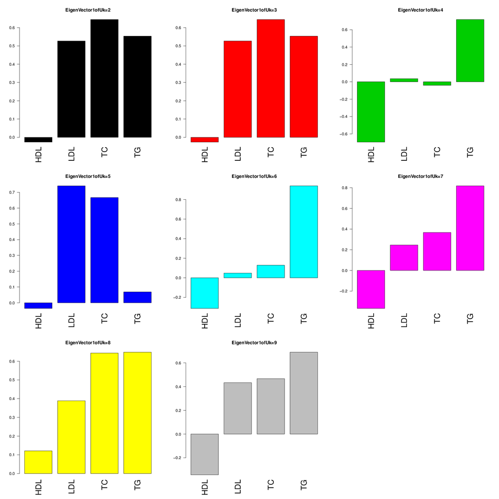

.

Note that Uk=5 and Uk=4, the most prevalent patterns by prior weight, capture strong correlations between LDL and Total Cholesterol (as seen in covariance of maxes) and inverse correlation between HDL and Triglycerides, also seen in the correlation matrix of maxes.